# R Notebook

## 4. Realice comentarios sobre el análisis estadístico de las variables numéricas y la gráfica de correlación.

Todas las variables analiazadas previamente cuentan con una excelente correlacion lo cual quere decir que pueden ser significativas para el modelo a desarrollar,

## 5. Realice un scatter plot de todas las variables numéricas contra la variable Chance of Admit.

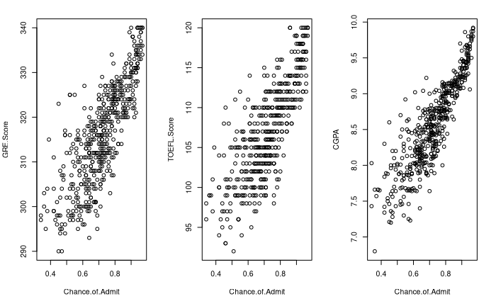

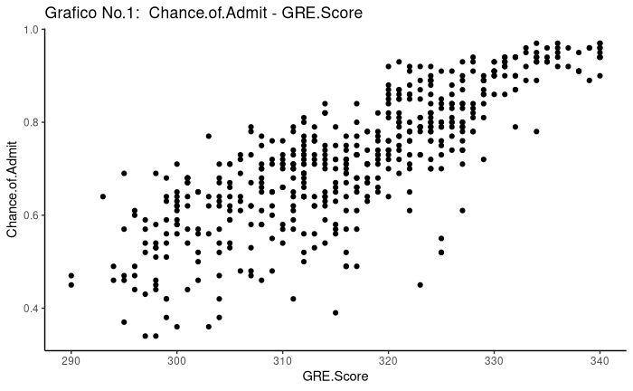

```r
library(ggplot2)
ggplot(df2, aes(x = GRE.Score, y = Chance.of.Admit)) +
  geom_point() +
  ggtitle("Grafico No.1:  Chance.of.Admit - GRE.Score") +
  theme_classic()
```

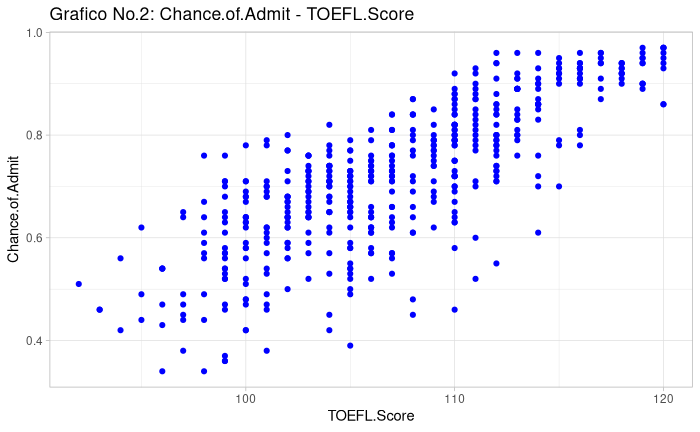

```r
ggplot(df2, aes(x = TOEFL.Score, y = Chance.of.Admit)) +
  geom_point(color="blue") +
  ggtitle("Grafico No.2: Chance.of.Admit - TOEFL.Score") +
  theme_light()
```

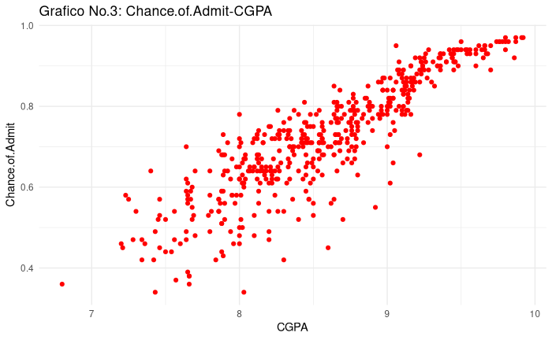

```r
ggplot(df2, aes(x = CGPA, y = Chance.of.Admit)) +
  geom_point(color="red") +
  ggtitle("Grafico No.3: Chance.of.Admit-CGPA") +
  theme_minimal()
```

## 6. Realice un modelo de regresión lineal simple con cada variable numérica como X y la variable Chance of Admit como Y.

```r
lms1 <- lm(Chance.of.Admit ~ GRE.Score, data = df2)
summary(lms1)
```

```
Call:
lm(formula = Chance.of.Admit ~ GRE.Score, data = df2)

Residuals:
     Min       1Q   Median       3Q      Max
-0.33784 -0.04479  0.00417  0.05449  0.18568

Coefficients:
              Estimate Std. Error t value Pr(>|t|)
(Intercept) -2.4828147  0.1038994  -23.90   <2e-16 ***
GRE.Score    0.0101259  0.0003281   30.86   <2e-16 ***
---
Signif. codes:  0 ‘***’ 0.001 ‘**’ 0.01 ‘*’ 0.05 ‘.’ 0.1 ‘ ’ 1

Residual standard error: 0.08278 on 498 degrees of freedom
Multiple R-squared:  0.6567,    Adjusted R-squared:  0.656
F-statistic: 952.5 on 1 and 498 DF,  p-value: < 2.2e-16
```

```r
lms2 <- lm(Chance.of.Admit ~ TOEFL.Score, data = df2)
summary(lms2)
```

```
Call:
lm(formula = Chance.of.Admit ~ TOEFL.Score, data = df2)

Residuals:
     Min       1Q   Median       3Q      Max
-0.31337 -0.04990  0.01310  0.05633  0.20725

Coefficients:
              Estimate Std. Error t value Pr(>|t|)
(Intercept) -1.2489882  0.0681317  -18.33   <2e-16 ***
TOEFL.Score  0.0183850  0.0006346   28.97   <2e-16 ***
---
Signif. codes:  0 ‘***’ 0.001 ‘**’ 0.01 ‘*’ 0.05 ‘.’ 0.1 ‘ ’ 1

Residual standard error: 0.08621 on 498 degrees of freedom
Multiple R-squared:  0.6276,    Adjusted R-squared:  0.6269
F-statistic: 839.4 on 1 and 498 DF,  p-value: < 2.2e-16
```

```r
lms3 <- lm(Chance.of.Admit ~ CGPA, data = df2)
summary(lms3)
```

```
Call:
lm(formula = Chance.of.Admit ~ CGPA, data = df2)

Residuals:
      Min        1Q    Median        3Q       Max
-0.276592 -0.028169  0.006619  0.038483  0.176961

Coefficients:
            Estimate Std. Error t value Pr(>|t|)
(Intercept) -1.04434    0.04230  -24.69   <2e-16 ***
CGPA         0.20592    0.00492   41.85   <2e-16 ***
---
Signif. codes:  0 ‘***’ 0.001 ‘**’ 0.01 ‘*’ 0.05 ‘.’ 0.1 ‘ ’ 1

Residual standard error: 0.06647 on 498 degrees of freedom
Multiple R-squared:  0.7787,    Adjusted R-squared:  0.7782
F-statistic:  1752 on 1 and 498 DF,  p-value: < 2.2e-16
```

## 7. Realice una gráfica de cada modelo de regresión lineal en su scatter plot correspondiente.

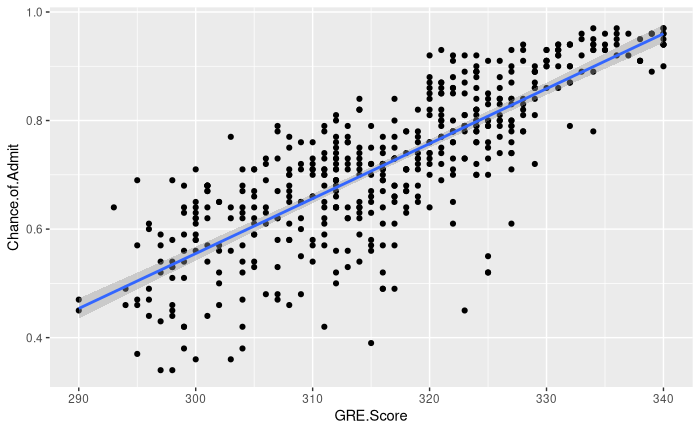

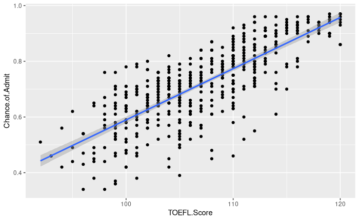

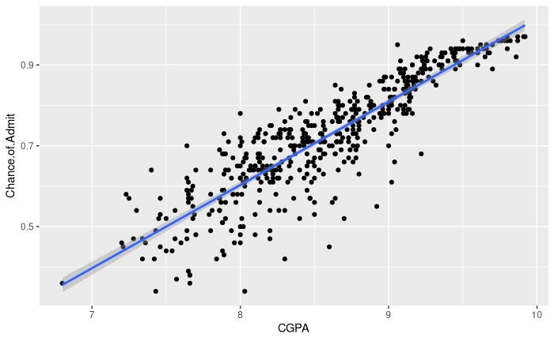

```r
ggplot(df2, aes(y=Chance.of.Admit, x=GRE.Score)) +
  geom_point()+
  geom_smooth(method=lm)

ggplot(df2, aes(y=Chance.of.Admit, x=TOEFL.Score)) +
  geom_point()+
  geom_smooth(method=lm)

ggplot(df2, aes(y=Chance.of.Admit, x=CGPA)) +
  geom_point()+
  geom_smooth(method=lm)
```

## Como en la Parte #2, realice un análisis sobre los resultados de cada modelo y diga cual de estos considera que es mejor y por que.

Dados los vaores obtenidos de los modelos de regresion , creeria que el mejor modelo es el lms3 el cual posse un r2 mas alto que los otrs dos sin llegar a considerarse sobredimensionado,los tres modelos tiene una asociacion estadisticamente significativa, adicionalmente el tercer modelos posee un RSE mas peque;o comparado con lso otros dos.

# Ejercicion # 3

## Modelo 1

El modelo muestra una relacion relacion de dos variables directamente dado que el primer y el tercer cuartil no son muy parecidos y dado que la media no es cero podemos decir que estos datos no poseen un distribucio normal.

Significancia individual: viene dada por la siguiente hipótesis:

Ho: Bi igual a cero (No significativo) H1: Bi distinto de cero (Significativo) Para nuestro caso utilizaremos el test a partir del p-Valor. En este caso, la regla de rechazo se establece alrededor del nivel de significancia, rechazamos la hipótesis en caso de que el p-valor sea inferior al nivel crítico elegido. Para ver esto más directamente, recordemos que el p.valor es una suma del área bajo la curva de densidad que esta entre el t calculado y el +inf, por lo que, esta solo será inferior al nivel crítico cuando el t.calculado sea inferior al t.tabla (teórico).

Significancia Global: Vine dada por la siguiente hipótesis: Ho: B1 = B2 = Bk = 0 (igual a cero) H1: B1 diferente B2 diferente Bk diferente de cero

## Modelo 2

El modelo muestra una relacion relacion de cuatro variables directamente dado que el primer y el tercer cuartil no son muy parecidos y dado que la media no es cero podemos decir que estos datos no poseen un distribucio normal.

Significancia Individual, viene dada por la siguiente hipótesis: Ho: Bi igual a cero (No significativo) H1: Bi distinto de cero (Significativo)

Significancia Global: Vine dada por la siguiente hipótesis: Ho: B1 = B2 = Bk = 0 (igual a cero) H1: B1 diferente B2 diferente Bk diferente de cero

A nivel global el modelo es estadísticamente significativo, sus p-valúes son menores que 5%, confirmando que las variables seleccionadas para predecir el comportamiento de Roll son estadísticamente significativas.

## Modelo 3

El modelo muestra una relacion relacion de 2 variables directamente dado que el primer y el tercer cuartil no son muy parecidos y dado que la media no es cero podemos decir que estos datos no poseen un distribucio normal.

Significancia Individual, viene dada por la siguiente hipótesis: Ho: Bi igual a cero (No significativo) H1: Bi distinto de cero (Significativo)

Significancia Global: Vine dada por la siguiente hipótesis: Ho: B1 = B2 = Bk = 0 (igual a cero) H1: B1 diferente B2 diferente Bk diferente de cero

A nivel global el modelo es estadísticamente significativo, su p-valúe es menor que 5%, confirmando que las variables seleccionadas para predecir el comportamiento de Roll son estadísticamente significativas.